# Tidy Tuesday: Plotting Geospatial Data in R

This notebook is intended to give you the basics of using the longitude and latitude data from the `water` dataset to get visualizations which involve maps. First, let’s load the (large) dataset:

```r
library(tidyverse)

water <- readr::read_csv('https://raw.githubusercontent.com/rfordatascience/tidytuesday/master/data/2021/2021-05-04/water.csv')
```

We will be using the `maps` library in R. If you have not installed this library yet, run

```r
install.packages("maps")
```

Plotting the coordinate data is not a big deal! First, we need to load the map data, which is part of the `maps` library. We can then use the `geom_polygon` layer from `ggplot()` to produce a map.

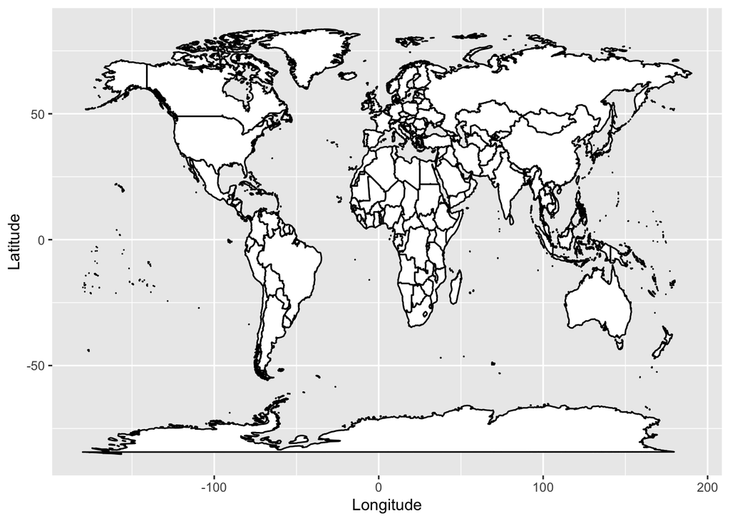

```r
library(maps)

world_map <- map_data("world")

world_map %>%
  ggplot(aes(long, lat, group = group)) +
  geom_polygon(fill = "white", color = "black") +
  labs(x = "Longitude", y = "Latitude")
```

Now, we can also use a `geom_point()` layer to add the coordinates from the `water` dataset, which are stored in the `lon_deg` and `lat_deg` columns. (Notice that I am not using a pipe `%>%` to feed in the dataset, since we are plotting using two *different* datasets and I was too lazy to merge them.)

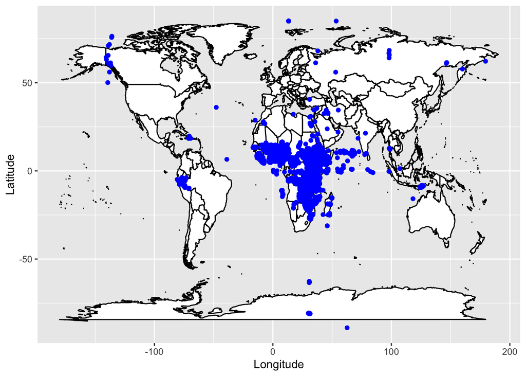

```r
ggplot() +
  geom_polygon(data = world_map, aes(long, lat, group = group), fill = "white", color = "black") +
  geom_point(data = water, aes(lon_deg, lat_deg), color = "blue") +
  labs(x = "Longitude", y = "Latitude")
```

Whoa! Something doesn’t look right here… and it turns out that it is the data itself! Some coordinates are correct, but others are way off in Antarctica! (You can confirm this by consulting the original data set.) It is a really good thing that we plotted this data- otherwise we might have used the `lon_deg` and `lat_deg` as predictors in a model. We are supposed to only be looking at African countries. How can we restrict our focus to only African countries?

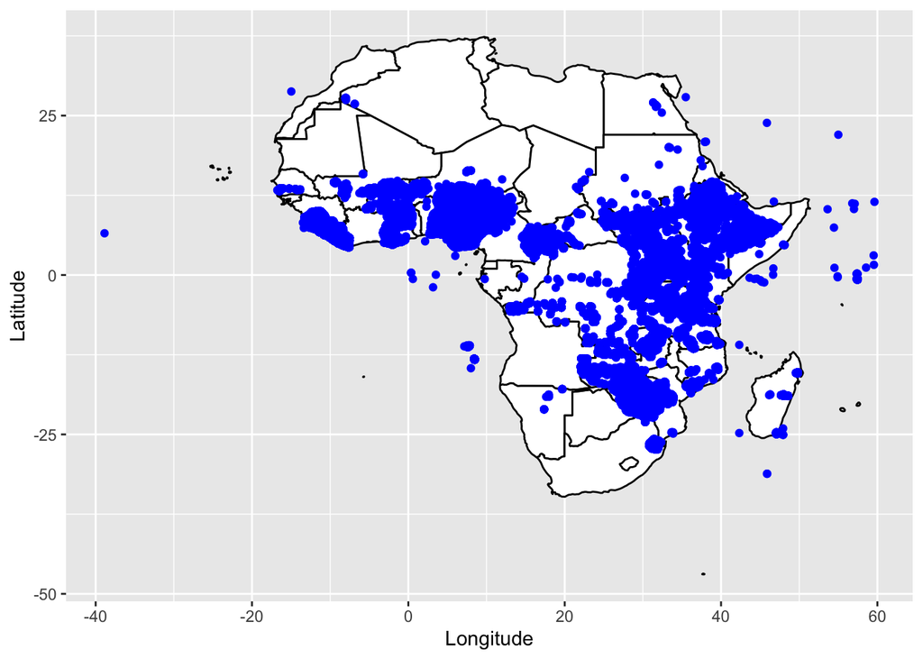

```r
#This pulls a dataset of country names, codes, continents, etc.
library(raster)
cc <- raster::ccodes()

#Pull the map data for the african countries only
africa_map <- map_data("world", regions = c(cc %>%
                                         filter(continent == "Africa") %>%
                                         pull(NAME)
                                         #For some reason Ivory Coast was left out of the cc dataset- this fixes it.
                                         , "Ivory Coast")
                       )

#Now we can plot the data. I am using the filter() function to restrict the geom_point() layer to coordinates that make sense for africa.
ggplot() +
  geom_polygon(data = africa_map, aes(long, lat, group = group), fill = "white", color = "black") +
  geom_point(data = (water %>%
                       filter(lon_deg > -50 & lon_deg < 60,
                              lat_deg > -40 & lat_deg < 30)
                       ), aes(lon_deg, lat_deg), color = "blue") +
  labs(x = "Longitude", y = "Latitude")
```

Making choropleth maps (maps colored according to the value from a dataframe) is also easy:

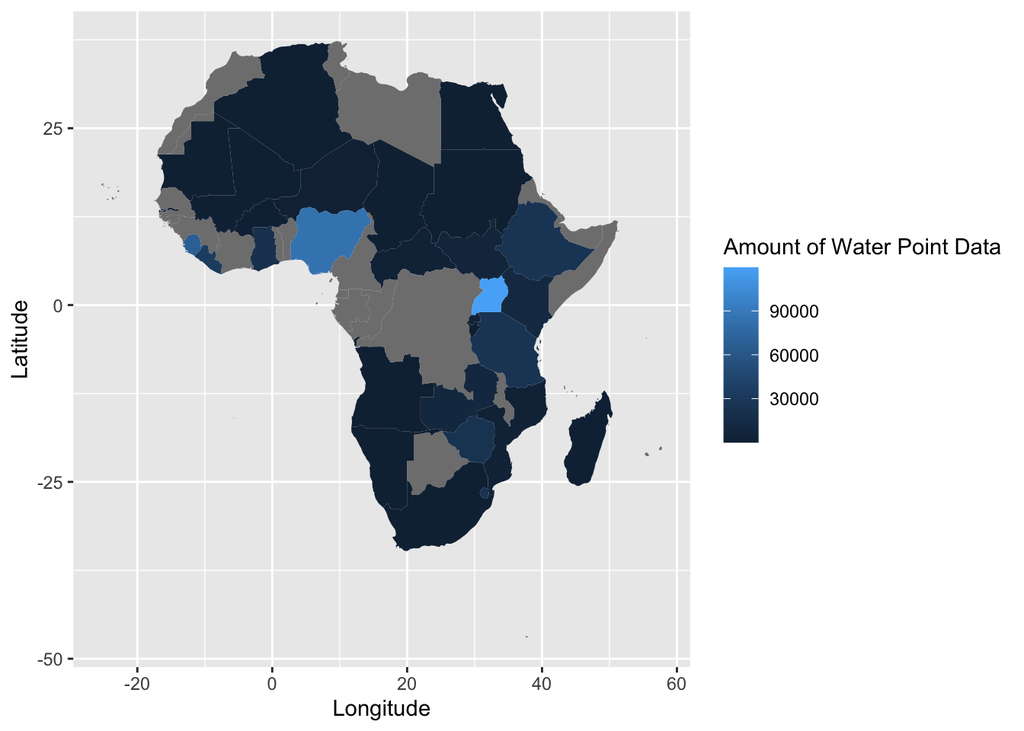

```r
africa_map %>%
  #Take the africa map dataset, and add on a column (from the count() function) named "n" which counts the number of data points that lie in each country_name level.
  left_join((water %>%
              count(country_name)
              ), by = c("region" = "country_name")) %>%
  #Now, plot as before, but say "fill = n" in the aes() argument. Recall that n is just the name of the column that you're getting the fill values from.
  ggplot(aes(long,lat, group = group, fill = n)) +
  geom_polygon() +
  labs(x = "Longitude", y = "Latitude", fill = "Amount of Water Point Data")
```